# nsl49_BTRY_6020_FinalProject

Nathan Lewis

2025-05-06

## Loading in the original datasets

```r
raw_data1 <- read.csv("test_energy_data.csv")
raw_data2 <- read.csv("train_energy_data.csv")
#merging the two datasets, would rather combine it all then make my own training/testing folds
raw_data <- rbind(raw_data1, raw_data2)
```

### Basically the exploratory data analysis section

## Perusing the original dataset - choosing Energy Consumption as my predicted variable

```r
library(corrplot) #library to view correlations, a more detailed description is given where this is used
#Initial output tables
head(raw_data)
```

|  | Building.Type | Square.Footage | Number.of.Occupants | Appliances.Used | Average.Temperature | Day.of.Week | Energy.Consumption |
| --- | --- | --- | --- | --- | --- | --- | --- |
| 1 | Residential | 24563 | 15 | 4 | 28.52 | Weekday | 2865.57 |
| 2 | Commercial | 27583 | 56 | 23 | 23.07 | Weekend | 4283.80 |
| 3 | Commercial | 45313 | 4 | 44 | 33.56 | Weekday | 5067.83 |
| 4 | Residential | 41625 | 84 | 17 | 27.39 | Weekend | 4624.30 |
| 5 | Residential | 36720 | 58 | 47 | 17.08 | Weekday | 4820.59 |
| 6 | Industrial | 31207 | 47 | 28 | 22.82 | Weekday | 5026.23 |

```r
#- used print bc it was displaying weird without it
print(summary(raw_data))
```

```
##  Building.Type      Square.Footage  Number.of.Occupants Appliances.Used
##  Length:1100        Min.   :  560   Min.   : 1.00       Min.   : 1.00
##  Class :character   1st Qu.:13204   1st Qu.:22.00       1st Qu.:13.00
##  Mode  :character   Median :25786   Median :47.00       Median :26.00
##                     Mean   :25501   Mean   :48.27       Mean   :25.73
##                     3rd Qu.:37537   3rd Qu.:73.00       3rd Qu.:38.00
##                     Max.   :49997   Max.   :99.00       Max.   :49.00
##  Average.Temperature Day.of.Week        Energy.Consumption
##  Min.   :10.05       Length:1100        Min.   :1684
##  1st Qu.:16.36       Class :character   1st Qu.:3510
##  Median :22.81       Mode  :character   Median :4190
##  Mean   :22.56                          Mean   :4168
##  3rd Qu.:28.76                          3rd Qu.:4860
##  Max.   :34.99                          Max.   :6531
```

```r
#Checking for any missing datapoints - printing to verify that it is 0
print(colSums(is.na(raw_data)))
```

```
##       Building.Type      Square.Footage Number.of.Occupants     Appliances.Used
##                   0                   0                   0                   0
## Average.Temperature         Day.of.Week  Energy.Consumption
##                   0                   0                   0
```

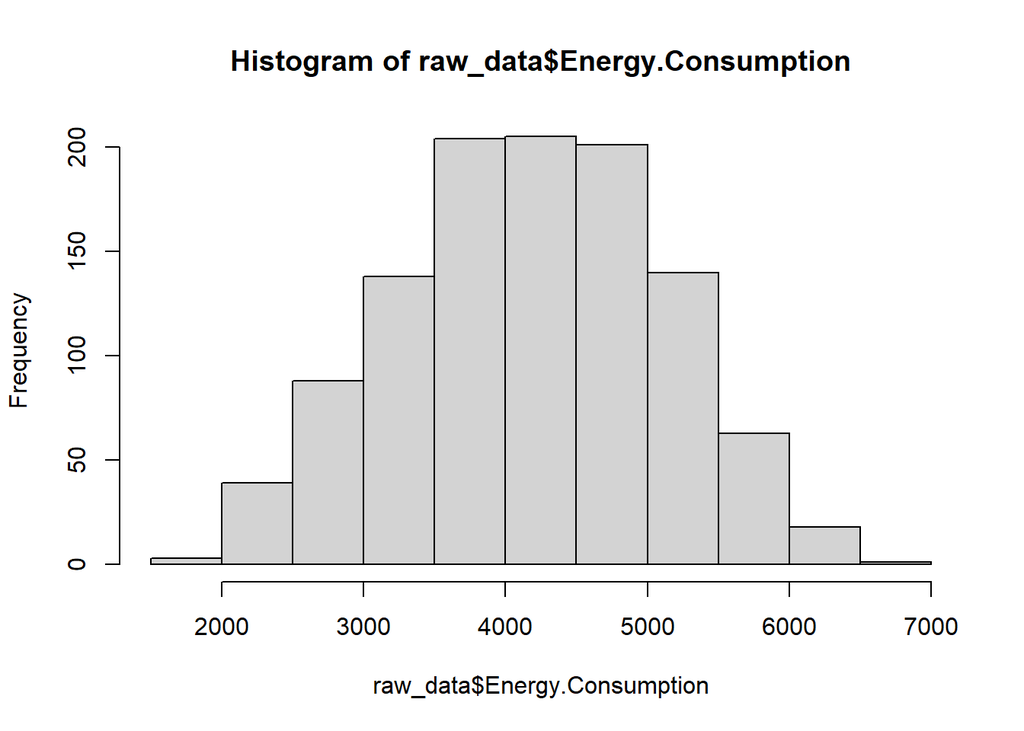

```r
#no missing data points, this was mentioned in Kaggle but needed to verify

#getting the Histogram of the energy consumption data
hist(raw_data$Energy.Consumption)
```

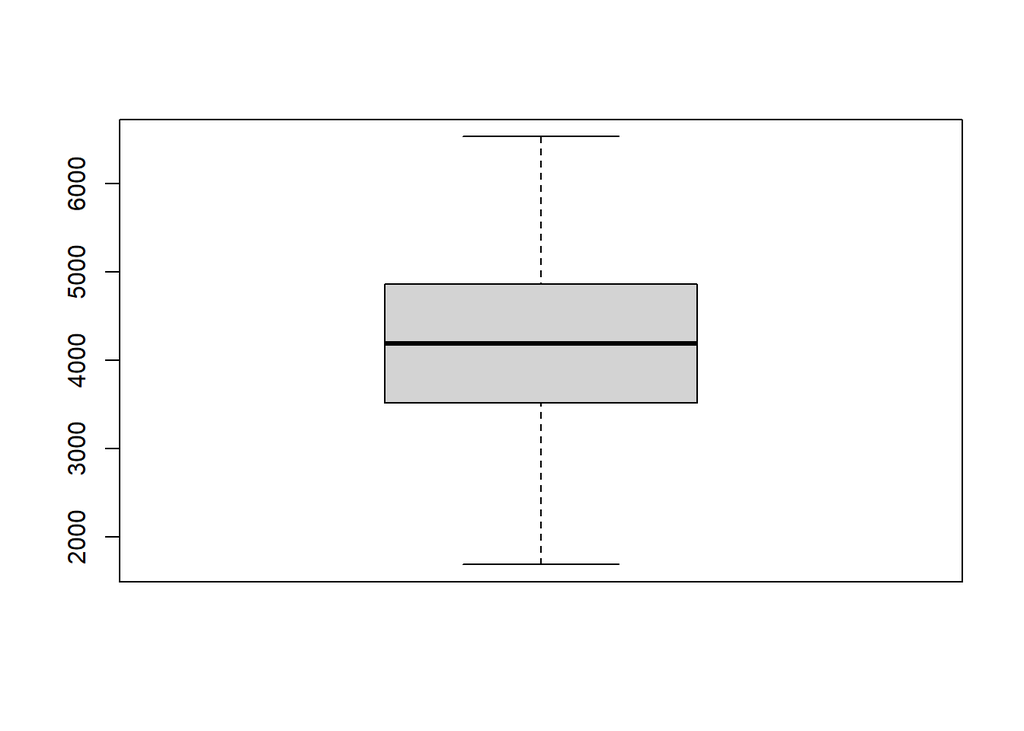

```r
#appears to be normally distributed centered around 4250 or so

#boxplot of energy consumption data
boxplot(raw_data$Energy.Consumption)
```

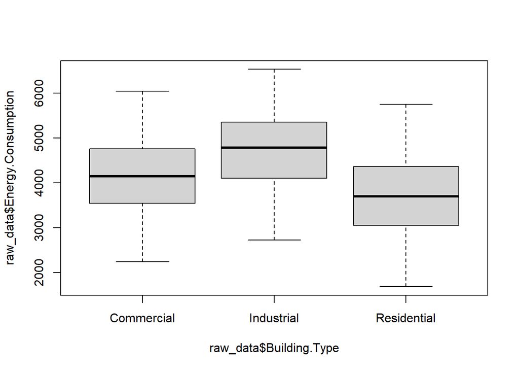

```r
##does not appear to be any outliers

## Linearity assessment of the categorical data, looking for outliers
boxplot(raw_data$Energy.Consumption ~ raw_data$Building.Type)
```

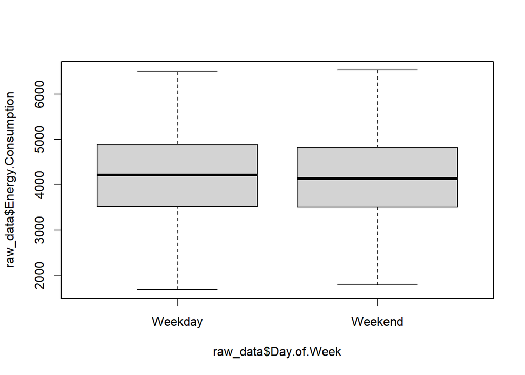

```r
boxplot(raw_data$Energy.Consumption ~ raw_data$Day.of.Week)
```

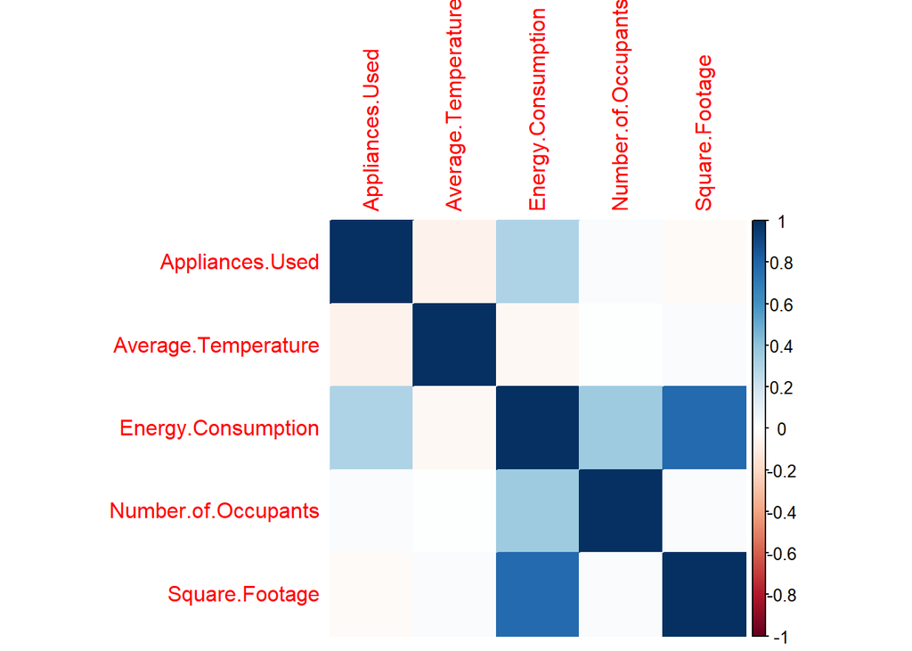

```r
## Day of week does not appear to make any difference, building type certainly looks to have a different mean but the distributions of each look the same
#wanted to check correlation between variables
#found an R package "corrplot" on the cran-r website with a quick google search - need to properly cite in citations
#https://cran.r-project.org/web/packages/corrplot/vignettes/corrplot-intro.html
#corrplot(raw_data, method = 'color', order = 'alphabet')
#originally got an error "The matrix is not in [-1, 1]

#first needed to convert them to numeric, thankfully this is the same as the as.factor logic which I have used previously
#filtering out the categorical variables to look at correlations
raw_data$Square.Footage <- as.numeric(raw_data$Square.Footage)
raw_data$Number.of.Occupants <- as.numeric(raw_data$Number.of.Occupants)
raw_data$Appliances.Used <- as.numeric(raw_data$Appliances.Used)
raw_data_numeric <- raw_data[, c(2, 3, 4, 5, 7)]

#creating the matrix
cor_matrix_raw_data <- cor(raw_data_numeric)
#now that I have the correlation matrix I can view it
corrplot(cor_matrix_raw_data, method = 'color', order = 'alphabet')
```

```r
#Energy consumption seems moderately correlated with square footage
#appears slightly correlated with appliances used and number of occupants
#does not seem very correlated with average temp
##all of the correlations seem low, this should take care of the multicollinearity assumption
```

### Regressions assumption verification

##Linearity assessment of all numeric predictors vs yield

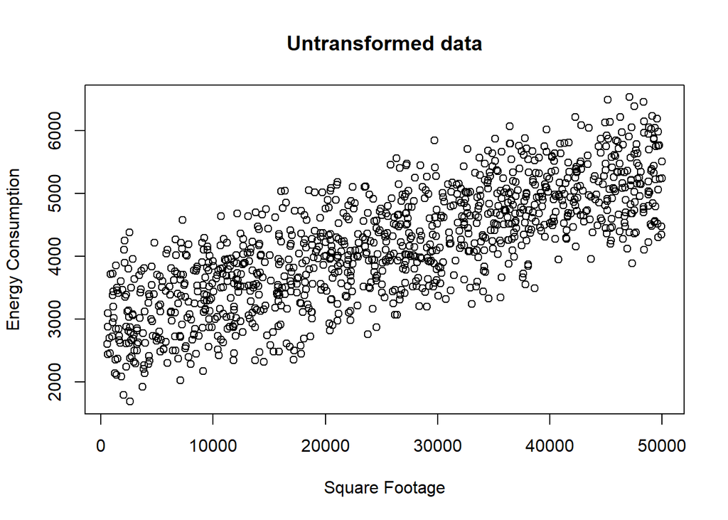

```r
##NUMERIC
#code adapted from Lab 2
plot(raw_data$Square.Footage, raw_data$Energy.Consumption, main = "Untransformed data", xlab = "Square Footage", ylab = "Energy Consumption")
```

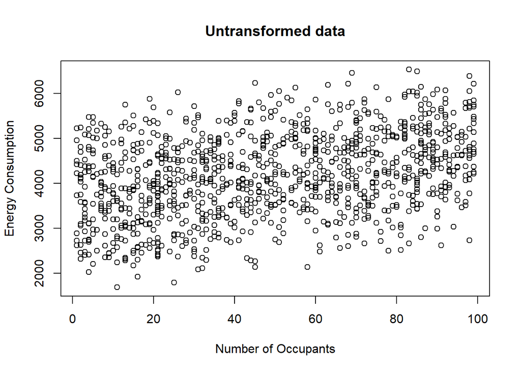

```r
#seems linear with a decent spread

plot(raw_data$Number.of.Occupants, raw_data$Energy.Consumption, main = "Untransformed data", xlab = "Number of Occupants", ylab = "Energy Consumption")
```

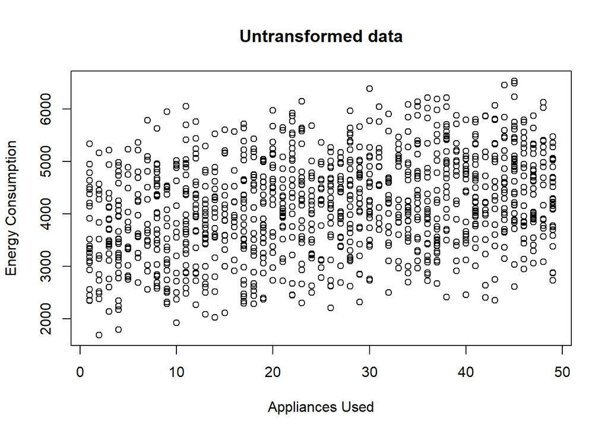

```r
#appears slightly linear with quite a bit of variation

plot(raw_data$Appliances.Used, raw_data$Energy.Consumption, main = "Untransformed data", xlab = "Appliances Used", ylab = "Energy Consumption")
```

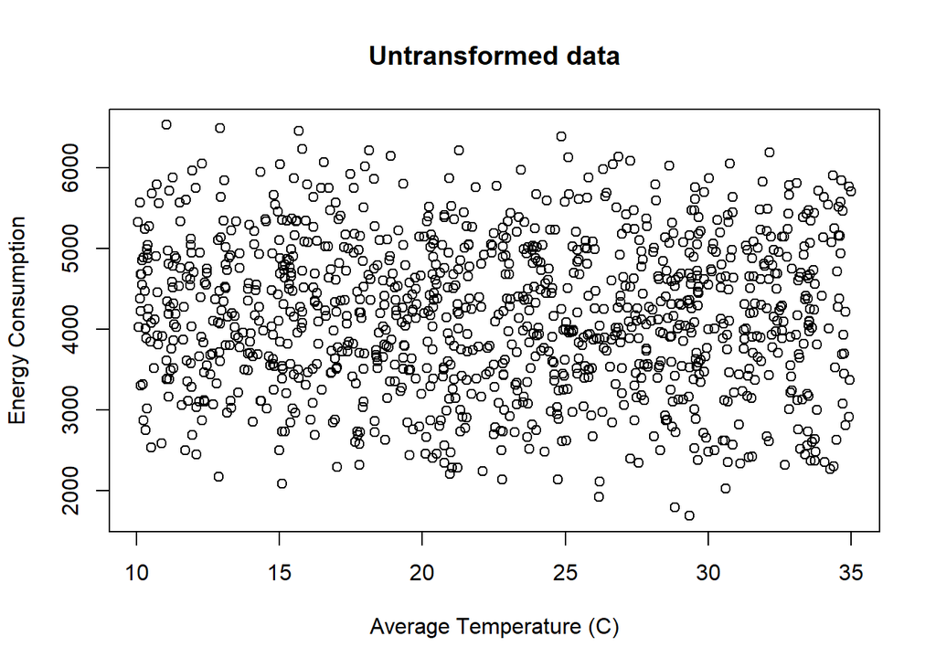

```r
#slight generally increasing linear trend but again a lot of variation

plot(raw_data$Average.Temperature, raw_data$Energy.Consumption, main = "Untransformed data", xlab = "Average Temperature (C)", ylab = "Energy Consumption")
```

```r
#potentially a slight downward trend, but appears more like random noise
```

#multicollinearity - looking at numeric correlations

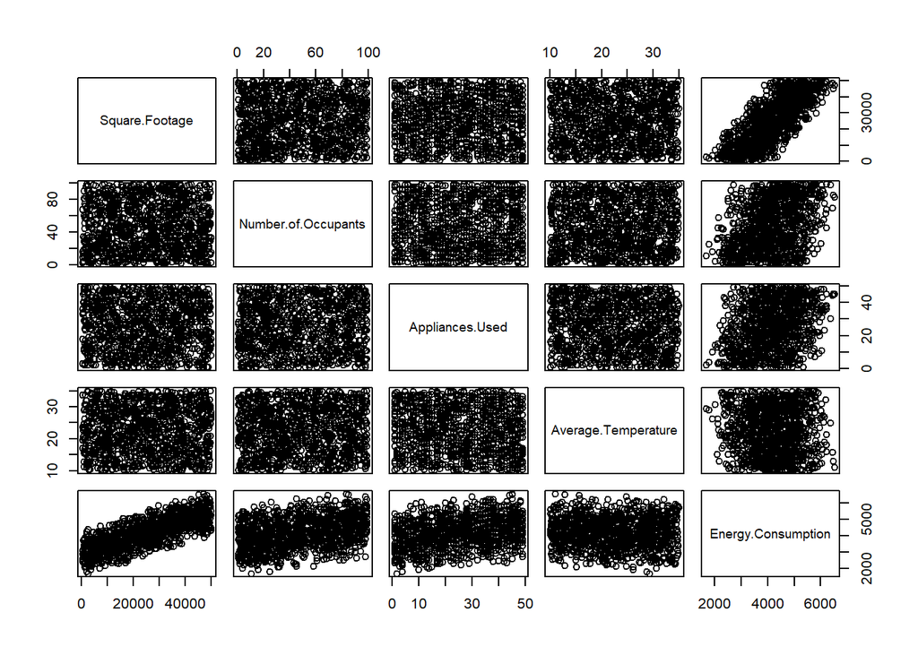

```r
pairs(raw_data_numeric)
```

```r
#does not appear to be any collinearity between the predictors, only between predictors and the energy consumption
```

#Homoskedasticity and Normality of Residuals #Looking into the residuals, did a simple linear model with each of the 4 numerics and the 2 categorical variables

```r
#code adapted from lab 3
## Continous variables
# Square footage
untransformed_sqft <- lm(Energy.Consumption ~ Square.Footage, data = raw_data)
summary(untransformed_sqft)
```

```
##
## Call:
## lm(formula = Energy.Consumption ~ Square.Footage, data = raw_data)
##
## Residuals:
##      Min       1Q   Median       3Q      Max
## -1403.12  -426.09     5.38   433.06  1461.27
##
## Coefficients:
##                 Estimate Std. Error t value Pr(>|t|)
## (Intercept)    2.892e+03  3.645e+01   79.34   <2e-16 ***
## Square.Footage 5.004e-02  1.248e-03   40.09   <2e-16 ***
## ---
## Signif. codes:  0 '***' 0.001 '**' 0.01 '*' 0.05 '.' 0.1 ' ' 1
##
## Residual standard error: 589.1 on 1098 degrees of freedom
## Multiple R-squared:  0.5941, Adjusted R-squared:  0.5937
## F-statistic:  1607 on 1 and 1098 DF,  p-value: < 2.2e-16
```

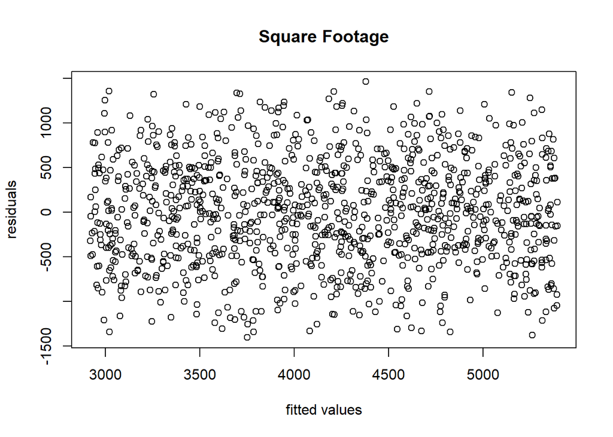

```r
plot(untransformed_sqft$fitted.values, untransformed_sqft$residuals, main = "Square Footage",
xlab = "fitted values", ylab = "residuals")
```

```r
# Number of Occupants
untransformed_occupants <- lm(Energy.Consumption ~ Number.of.Occupants, data = raw_data)
summary(untransformed_occupants)
```

```
##
## Call:
## lm(formula = Energy.Consumption ~ Number.of.Occupants, data = raw_data)
##
## Residuals:
##      Min       1Q   Median       3Q      Max
## -2139.01  -640.11   -14.81   646.17  2108.25
##
## Coefficients:
##                     Estimate Std. Error t value Pr(>|t|)
## (Intercept)         3631.686     50.561   71.83   <2e-16 ***
## Number.of.Occupants   11.115      0.897   12.39   <2e-16 ***
## ---
## Signif. codes:  0 '***' 0.001 '**' 0.01 '*' 0.05 '.' 0.1 ' ' 1
##
## Residual standard error: 866.1 on 1098 degrees of freedom
## Multiple R-squared:  0.1227, Adjusted R-squared:  0.1219
## F-statistic: 153.6 on 1 and 1098 DF,  p-value: < 2.2e-16
```

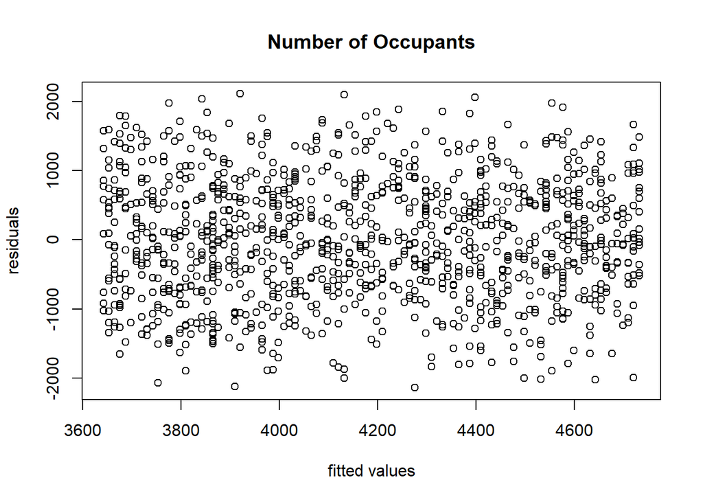

```r
plot(untransformed_occupants$fitted.values, untransformed_occupants$residuals, main = "Number of Occupants",
xlab = "fitted values", ylab = "residuals")
```

```r
# Appliances used
untransformed_appliances <- lm(Energy.Consumption ~ Appliances.Used, data = raw_data)
summary(untransformed_appliances)
```

```
##
## Call:
## lm(formula = Energy.Consumption ~ Appliances.Used, data = raw_data)
##
## Residuals:
##      Min       1Q   Median       3Q      Max
## -2157.16  -634.10     1.45   638.69  2176.28
##
## Coefficients:
##                 Estimate Std. Error t value Pr(>|t|)
## (Intercept)     3660.244     55.287   66.20   <2e-16 ***
## Appliances.Used   19.741      1.884   10.48   <2e-16 ***
## ---
## Signif. codes:  0 '***' 0.001 '**' 0.01 '*' 0.05 '.' 0.1 ' ' 1
##
## Residual standard error: 881.7 on 1098 degrees of freedom
## Multiple R-squared:  0.09091,    Adjusted R-squared:  0.09008
## F-statistic: 109.8 on 1 and 1098 DF,  p-value: < 2.2e-16
```

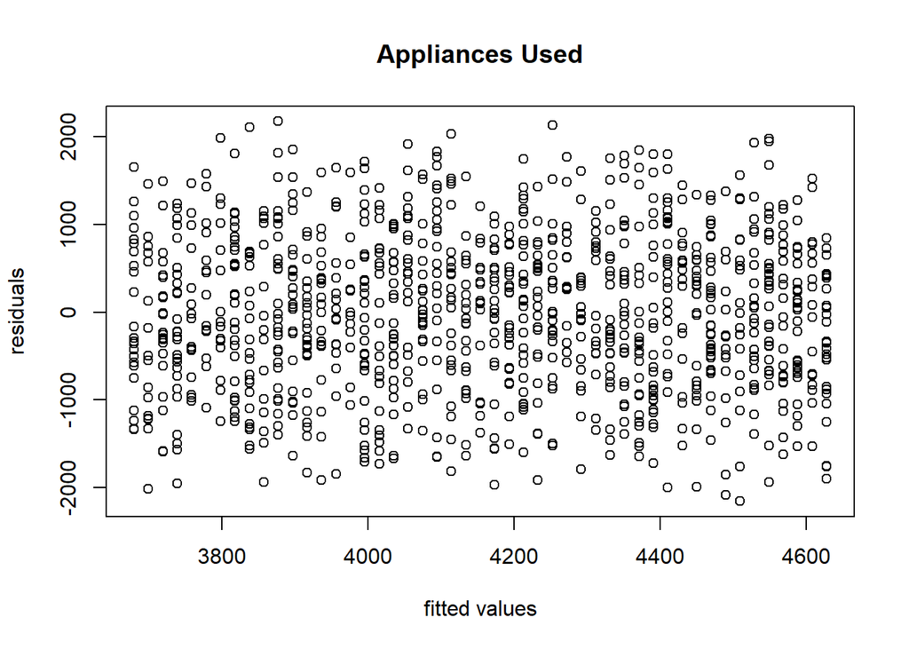

```r
plot(untransformed_appliances$fitted.values, untransformed_appliances$residuals, main = "Appliances Used",
xlab = "fitted values", ylab = "residuals")
```

```r
# Number of Occupants
untransformed_temp <- lm(Energy.Consumption ~ Average.Temperature, data = raw_data)
summary(untransformed_temp)
```

```
##
## Call:
## lm(formula = Energy.Consumption ~ Average.Temperature, data = raw_data)
##
## Residuals:
##      Min       1Q   Median       3Q      Max
## -2450.62  -665.95    10.07   676.45  2305.34
##
## Coefficients:
##                     Estimate Std. Error t value Pr(>|t|)
## (Intercept)         4280.045     92.578  46.232   <2e-16 ***
## Average.Temperature   -4.958      3.913  -1.267    0.205
## ---
## Signif. codes:  0 '***' 0.001 '**' 0.01 '*' 0.05 '.' 0.1 ' ' 1
##
## Residual standard error: 924 on 1098 degrees of freedom
## Multiple R-squared:  0.00146,    Adjusted R-squared:  0.0005503
## F-statistic: 1.605 on 1 and 1098 DF,  p-value: 0.2054
```

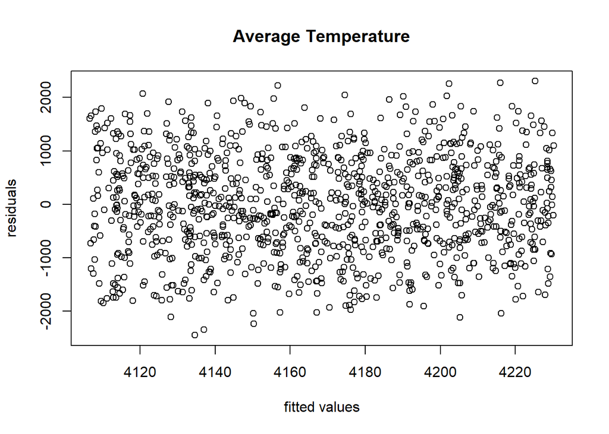

```r
plot(untransformed_temp$fitted.values, untransformed_temp$residuals, main = "Average Temperature",
xlab = "fitted values", ylab = "residuals")
```

```r
## all of these predictors appear to have homoscedasticity, the residuals are randomly spread and do not show any funnelling

## Categorical variables
# Square footage
untransformed_day <- lm(Energy.Consumption ~ Day.of.Week, data = raw_data)
summary(untransformed_day)
```

```
##
## Call:
## lm(formula = Energy.Consumption ~ Day.of.Week, data = raw_data)
##
## Residuals:
##      Min       1Q   Median       3Q      Max
## -2500.36  -655.65    18.73   698.22  2378.59
##
## Coefficients:
##                    Estimate Std. Error t value Pr(>|t|)
## (Intercept)         4184.31      39.39 106.235   <2e-16 ***
## Day.of.WeekWeekend   -32.31      55.75  -0.579    0.562
## ---
## Signif. codes:  0 '***' 0.001 '**' 0.01 '*' 0.05 '.' 0.1 ' ' 1
##
## Residual standard error: 924.6 on 1098 degrees of freedom
## Multiple R-squared:  0.0003057,  Adjusted R-squared:  -0.0006048
## F-statistic: 0.3358 on 1 and 1098 DF,  p-value: 0.5624
```

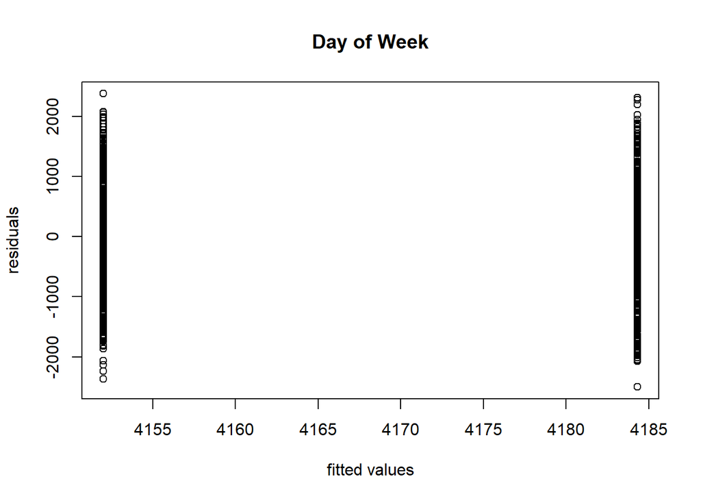

```r
plot(untransformed_day$fitted.values, untransformed_day$residuals, main = "Day of Week",
xlab = "fitted values", ylab = "residuals")
```

```r
# Number of Occupants
untransformed_type <- lm(Energy.Consumption ~ Building.Type, data = raw_data)
summary(untransformed_type)
```

```
##
## Call:
## lm(formula = Energy.Consumption ~ Building.Type, data = raw_data)
##
## Residuals:
##      Min       1Q   Median       3Q      Max
## -2001.52  -617.05    29.41   645.23  2060.93
##
## Coefficients:
##                          Estimate Std. Error t value Pr(>|t|)
## (Intercept)               4152.75      43.26  95.998  < 2e-16 ***
## Building.TypeIndustrial    563.61      61.65   9.141  < 2e-16 ***
## Building.TypeResidential  -467.28      60.18  -7.765 1.87e-14 ***
## ---
## Signif. codes:  0 '***' 0.001 '**' 0.01 '*' 0.05 '.' 0.1 ' ' 1
##
## Residual standard error: 823.1 on 1097 degrees of freedom
## Multiple R-squared:  0.2085, Adjusted R-squared:  0.207
## F-statistic: 144.5 on 2 and 1097 DF,  p-value: < 2.2e-16
```

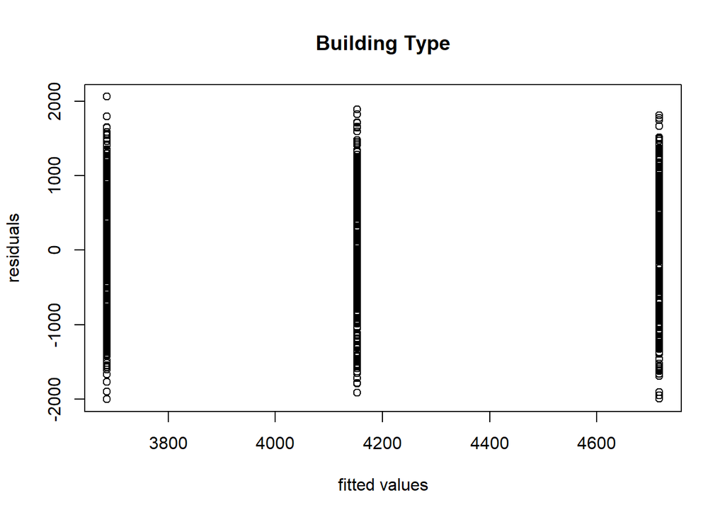

```r
plot(untransformed_type$fitted.values, untransformed_type$residuals, main = "Building Type",
xlab = "fitted values", ylab = "residuals")
```

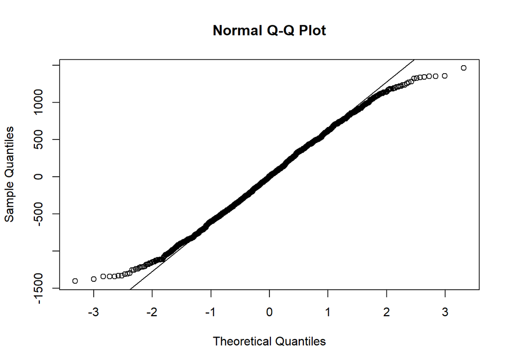

```r
#residuals appear to be the same for all three levels of the building type and both levels for the day of the week

# Homoskedasticity assumption is good, now to check normality of residuals
qqnorm(untransformed_sqft$residuals)
qqline(untransformed_sqft$residuals)
```

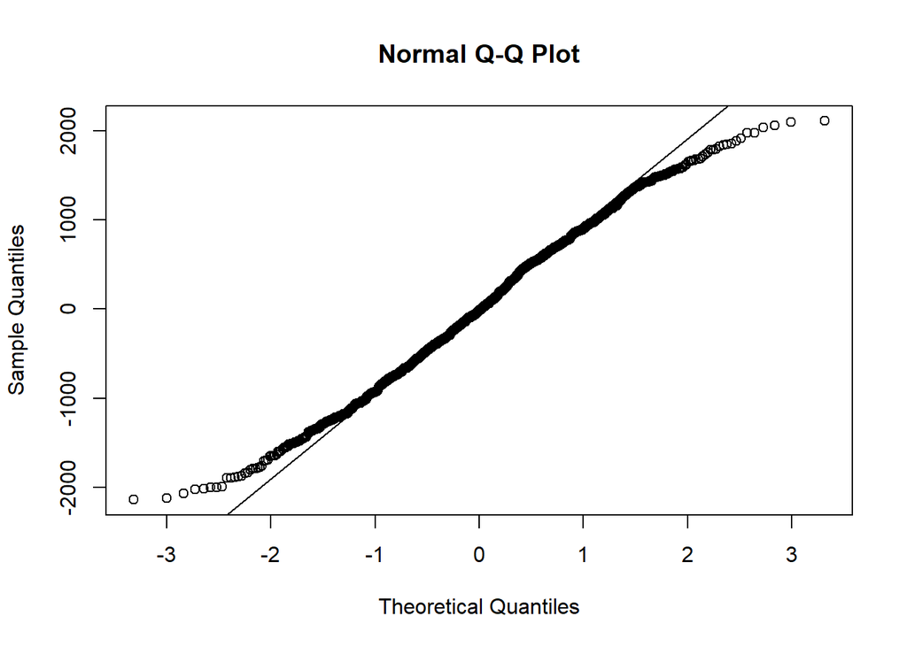

```r
qqnorm(untransformed_occupants$residuals)
qqline(untransformed_occupants$residuals)
```

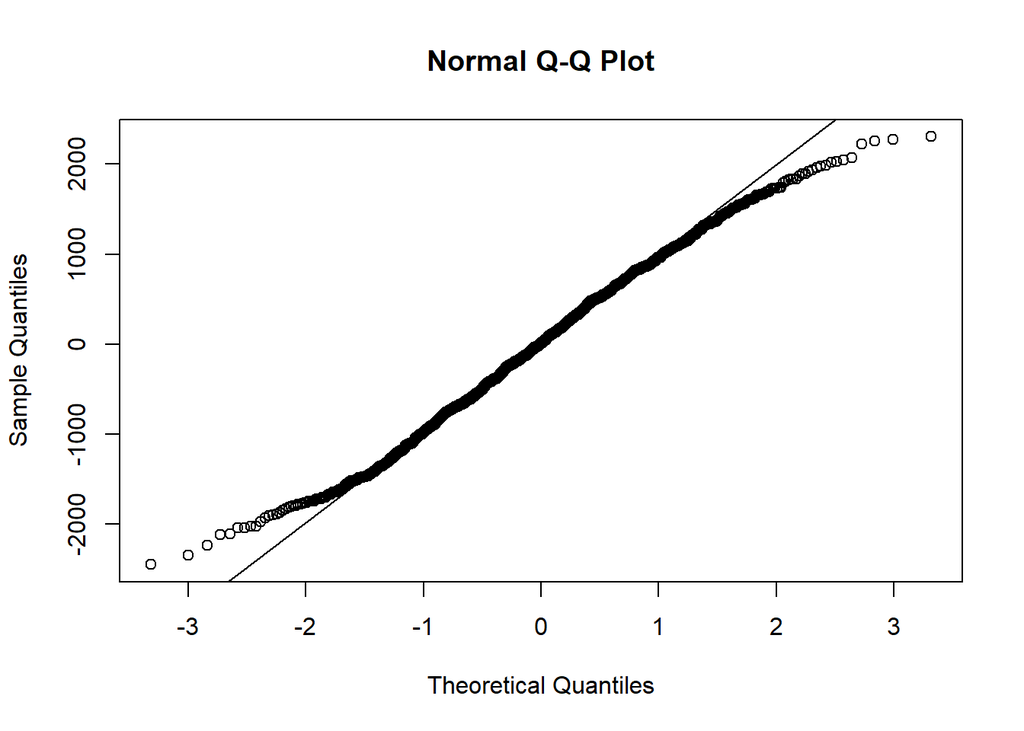

```r
qqnorm(untransformed_temp$residuals)
qqline(untransformed_temp$residuals)
```

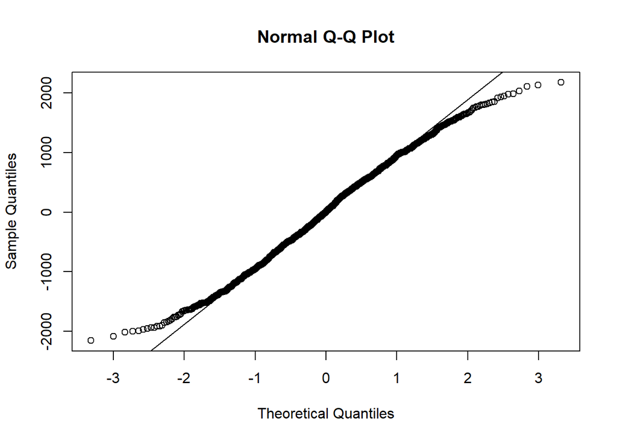

```r
qqnorm(untransformed_appliances$residuals)
qqline(untransformed_appliances$residuals)
```

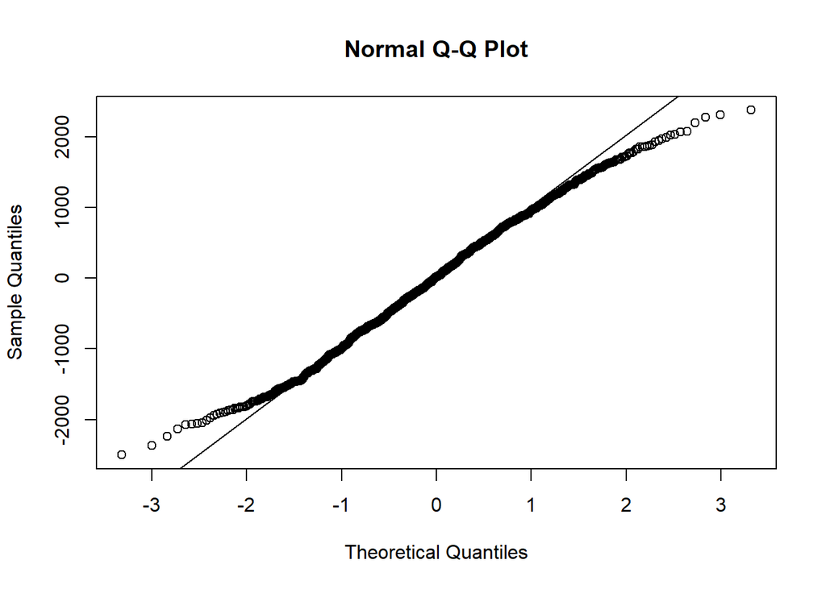

```r
qqnorm(untransformed_day$residuals)
qqline(untransformed_day$residuals)
```

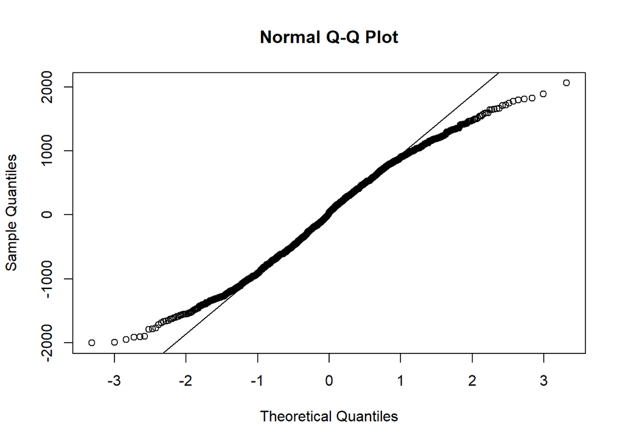

```r
qqnorm(untransformed_type$residuals)
qqline(untransformed_type$residuals)
```

```r
## All six of these do not seem to fit the normality of residuals assumption
## However, n in this case is large (1100 >>> 30), so by Central Limit theorem I should be okay


# Day of Week and Temperature are not significant, all other ones are significant
```

## Independence of observations - no way to know with this dataset, could potentially be the same buildings sampled multi times

### Assumption violation handling - only one violated is normality of residuals, this should be okay via the Central Limit Theorem since n >> 30

### Variable Selection 1 - Forward Selection

## Going to use the BIC rather than AIC since n is large (1000 after splitting)

### While I initially used BIC over AIC to prevent overfitting, I could not figure out how to run BIC on the Cross Validation approach within cv.glm, for this reason, I decided to go back and use AIC rather than BIC so that it was the same for both model approaches

Forward Selection BIC approach - did not end up using

```r
library("boot")
#code adapted from lab 8 & 9
set.seed(999)

#Forward selection
#reading in the length of rows in the dataset with nrow
#tried length() at first but gave number of columns
n <- nrow(raw_data)

##smallest model
interceptonly <- lm(Energy.Consumption ~ 1, data = raw_data)
##largest model
largest <- lm(Energy.Consumption ~ ., data = raw_data)
#since I am using the step function I need to select the smallest AIC, not the largest - not from Lab 9
out_forward_bic <- step(object = interceptonly, direction = "forward", scope = formula(largest), trace = T, k = log(n))
```

```
## Start:  AIC=15029.83
## Energy.Consumption ~ 1
##
##                       Df Sum of Sq       RSS   AIC
## + Square.Footage       1 557759603 381106378 14045
## + Building.Type        2 195735403 743130578 14787
## + Number.of.Occupants  1 115195040 823670942 14893
## + Appliances.Used      1  85347619 853518363 14932
## <none>                             938865982 15030
## + Average.Temperature  1   1370487 937495495 15035
## + Day.of.Week          1    287004 938578978 15036
##
## Step:  AIC=14045.08
## Energy.Consumption ~ Square.Footage
##
##                       Df Sum of Sq       RSS   AIC
## + Building.Type        2 192569579 188536799 13285
## + Number.of.Occupants  1 103821471 277284908 13702
## + Appliances.Used      1  96583813 284522565 13731
## + Average.Temperature  1   3302814 377803565 14042
## <none>                             381106378 14045
## + Day.of.Week          1    140291 380966088 14052
##
## Step:  AIC=13284.92
## Energy.Consumption ~ Square.Footage + Building.Type
##
##                       Df Sum of Sq       RSS   AIC
## + Number.of.Occupants  1  97298176  91238623 12494
## + Appliances.Used      1  93847130  94689669 12534
## + Average.Temperature  1   3030343 185506456 13274
## <none>                             188536799 13285
## + Day.of.Week          1    650725 187886074 13288
##
## Step:  AIC=12493.53
## Energy.Consumption ~ Square.Footage + Building.Type + Number.of.Occupants
##
##                       Df Sum of Sq      RSS     AIC
## + Appliances.Used      1  89215432  2023191  8310.9
## + Average.Temperature  1   3255621 87983002 12460.6
## + Day.of.Week          1    882102 90356521 12489.8
## <none>                             91238623 12493.5
##
## Step:  AIC=8310.85
## Energy.Consumption ~ Square.Footage + Building.Type + Number.of.Occupants +
##     Appliances.Used
##
##                       Df Sum of Sq     RSS    AIC
## + Average.Temperature  1   1337070  686121 7128.3
## + Day.of.Week          1    640390 1382801 7899.2
## <none>                             2023191 8310.9
##
## Step:  AIC=7128.34
## Energy.Consumption ~ Square.Footage + Building.Type + Number.of.Occupants +
##     Appliances.Used + Average.Temperature
##
##               Df Sum of Sq    RSS     AIC
## + Day.of.Week  1    686121      0 -9383.7
## <none>                     686121  7128.3
##
## Step:  AIC=-9383.66
## Energy.Consumption ~ Square.Footage + Building.Type + Number.of.Occupants +
##     Appliances.Used + Average.Temperature + Day.of.Week
```

```r
summary(out_forward_bic)
```

```
##
## Call:
## lm(formula = Energy.Consumption ~ Square.Footage + Building.Type +
##     Number.of.Occupants + Appliances.Used + Average.Temperature +
##     Day.of.Week, data = raw_data)
##
## Residuals:
##        Min         1Q     Median         3Q        Max
## -0.0212656 -0.0104250  0.0000368  0.0103475  0.0213463
##
## Coefficients:
##                            Estimate Std. Error t value Pr(>|t|)
## (Intercept)               2.050e+03  2.008e-03 1020720   <2e-16 ***
## Square.Footage            5.000e-02  2.917e-08 1714321   <2e-16 ***
## Building.TypeIndustrial   5.000e+02  1.031e-03  484955   <2e-16 ***
## Building.TypeResidential -5.000e+02  1.007e-03 -496750   <2e-16 ***
## Number.of.Occupants       1.000e+01  1.425e-05  701815   <2e-16 ***
## Appliances.Used           2.000e+01  2.947e-05  678706   <2e-16 ***
## Average.Temperature      -5.000e+00  5.844e-05  -85556   <2e-16 ***
## Day.of.WeekWeekend       -5.000e+01  8.297e-04  -60266   <2e-16 ***
## ---
## Signif. codes:  0 '***' 0.001 '**' 0.01 '*' 0.05 '.' 0.1 ' ' 1
##
## Residual standard error: 0.01374 on 1092 degrees of freedom
## Multiple R-squared:      1,  Adjusted R-squared:      1
## F-statistic: 7.1e+11 on 7 and 1092 DF,  p-value: < 2.2e-16
```

Forward Selection - AIC - the same model final model was fit with both AIC and BIC

```r
library("boot")
#code adapted from lab 8 & 9
set.seed(999)

#Forward selection
#reading in the length of rows in the dataset with nrow
#tried length() at first but gave number of columns
n <- nrow(raw_data)

##smallest model
interceptonly <- glm(Energy.Consumption ~ 1, data = raw_data)
##largest model
largest <- glm(Energy.Consumption ~ ., data = raw_data)
#since I am using the step function I need to select the smallest AIC, not the largest - not from Lab 9
out_forward_aic <- step(object = interceptonly, direction = "forward", scope = formula(largest), trace = T, k = 2)
```

```
## Start:  AIC=18148.49
## Energy.Consumption ~ 1
##
##                       Df  Deviance   AIC
## + Square.Footage       1 381106378 17159
## + Building.Type        2 743130578 17895
## + Number.of.Occupants  1 823670942 18007
## + Appliances.Used      1 853518363 18046
## <none>                   938865982 18149
## + Average.Temperature  1 937495495 18149
## + Day.of.Week          1 938578978 18150
##
## Step:  AIC=17158.74
## Energy.Consumption ~ Square.Footage
##
##                       Df  Deviance   AIC
## + Building.Type        2 188536799 16389
## + Number.of.Occupants  1 277284908 16811
## + Appliances.Used      1 284522565 16839
## + Average.Temperature  1 377803565 17151
## <none>                   381106378 17159
## + Day.of.Week          1 380966088 17160
##
## Step:  AIC=16388.58
## Energy.Consumption ~ Square.Footage + Building.Type
##
##                       Df  Deviance   AIC
## + Number.of.Occupants  1  91238623 15592
## + Appliances.Used      1  94689669 15633
## + Average.Temperature  1 185506456 16373
## + Day.of.Week          1 187886074 16387
## <none>                   188536799 16389
##
## Step:  AIC=15592.18
## Energy.Consumption ~ Square.Footage + Building.Type + Number.of.Occupants
##
##                       Df Deviance   AIC
## + Appliances.Used      1  2023191 11404
## + Average.Temperature  1 87983002 15554
## + Day.of.Week          1 90356521 15584
## <none>                   91238623 15592
##
## Step:  AIC=11404.5
## Energy.Consumption ~ Square.Footage + Building.Type + Number.of.Occupants +
##     Appliances.Used
##
##                       Df Deviance   AIC
## + Average.Temperature  1   686121 10217
## + Day.of.Week          1  1382801 10988
## <none>                    2023191 11404
##
## Step:  AIC=10216.98
## Energy.Consumption ~ Square.Footage + Building.Type + Number.of.Occupants +
##     Appliances.Used + Average.Temperature
##
##               Df Deviance   AIC
## + Day.of.Week  1        0 -6300
## <none>             686121 10217
##
## Step:  AIC=-6300.02
## Energy.Consumption ~ Square.Footage + Building.Type + Number.of.Occupants +
##     Appliances.Used + Average.Temperature + Day.of.Week
```

```r
summary(out_forward_aic)
```

```
##
## Call:
## glm(formula = Energy.Consumption ~ Square.Footage + Building.Type +
##     Number.of.Occupants + Appliances.Used + Average.Temperature +
##     Day.of.Week, data = raw_data)
##
## Coefficients:
##                            Estimate Std. Error t value Pr(>|t|)
## (Intercept)               2.050e+03  2.008e-03 1020720   <2e-16 ***
## Square.Footage            5.000e-02  2.917e-08 1714321   <2e-16 ***
## Building.TypeIndustrial   5.000e+02  1.031e-03  484955   <2e-16 ***
## Building.TypeResidential -5.000e+02  1.007e-03 -496750   <2e-16 ***
## Number.of.Occupants       1.000e+01  1.425e-05  701815   <2e-16 ***
## Appliances.Used           2.000e+01  2.947e-05  678706   <2e-16 ***
## Average.Temperature      -5.000e+00  5.844e-05  -85556   <2e-16 ***
## Day.of.WeekWeekend       -5.000e+01  8.297e-04  -60266   <2e-16 ***
## ---
## Signif. codes:  0 '***' 0.001 '**' 0.01 '*' 0.05 '.' 0.1 ' ' 1
##
## (Dispersion parameter for gaussian family taken to be 0.000188912)
##
##     Null deviance: 9.3887e+08  on 1099  degrees of freedom
## Residual deviance: 2.0629e-01  on 1092  degrees of freedom
## AIC: -6300
##
## Number of Fisher Scoring iterations: 2
```